# Course 8 Prediction Assignment

Jianjun Ge

August 11, 2017

## Summary

This is the course 8 assignment poject. The goal of this project is to use data from accelerometers on the belt, forearm, arm, etc to predict the manner in which six participants did the excise.

## Load & Explore Data

```r
library(randomForest)
library(caret)
```

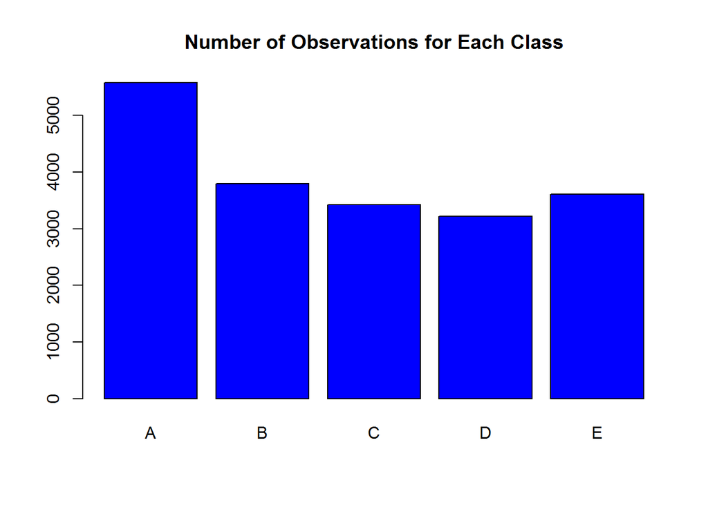

```r
pml.training <- read.csv("../08/pml-training.csv", header = TRUE)
dim(pml.training)
str(pml.training)
barplot(table(pml.training$classe),
        main = "Number of Observations for Each Class", col = "blue")
```

## Preprocessing Data

The trainning data appear to have lots of NA and empty observations. The first step is to find out the number of NA or empty obs in each column.

```r
pml.training[pml.training == ""] <- NA
pml.na <- apply(pml.training, 2, function(y) sum(is.na(y)))
```

Then, columns with more than 1000 NA/empty are removed. The beginning 6 columns are also removed for modeling because user_name and recording time related variables are not likely to be useful for predicting excercise manners.

```r
pml.naremov <- pml.training[, pml.na < 1000]
pml.new <- pml.naremov[,-(1:6)]
dim(pml.new)
```

```
## [1] 19622    54
```

## Random Forest Modeling

Random forest is chosen because of the relatively large number of observations and features of this dataset. RF is easy to train and can provide relative importance ranking of each predictors. RF is often used as benchmark models.

The trainning dataset is first broken into two parts: trainning (70%) and validation (30%).

```r
train.ind <- sample(c(1:2), dim(pml.new)[1], replace = T, prob = c(0.7,0.3))
pml.new.train <- pml.new[train.ind == 1, ]
pml.new.valid <- pml.new[train.ind == 2, ]
table(pml.new.valid$classe)
```

```
##
##    A    B    C    D    E
## 1624 1164 1018  930 1079
```

Run RF on trainning data:

```r
rf.1 <- randomForest(classe ~ ., data=pml.new.train)
rf.1
```

```
##
## Call:
##  randomForest(formula = classe ~ ., data = pml.new.train)
##                Type of random forest: classification
##                      Number of trees: 500
## No. of variables tried at each split: 7
##
##         OOB estimate of  error rate: 0.23%
## Confusion matrix:
##      A    B    C    D    E class.error
## A 3956    0    0    0    0 0.000000000
## B    3 2629    1    0    0 0.001519180
## C    0   11 2392    1    0 0.004991681
## D    0    0   10 2276    0 0.004374453
## E    0    0    0    6 2522 0.002373418
```

Importance of predictors from this RF model:

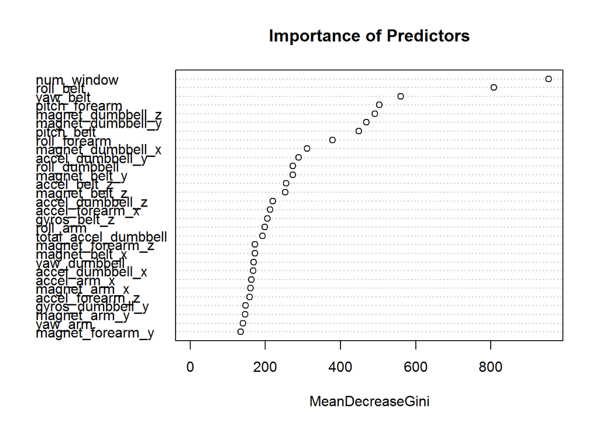

```r
varImpPlot(rf.1, main = "Importance of Predictors")
```

This plot shows that “num_window”, “roll_belt”, and “yaw_belt” are top three most important variables in predicting exercise manner classes.

Cross validation using the rest of the trainning data (30%):

```r
pred <- predict(rf.1, pml.new.valid)
table(pred, pml.new.valid$classe)
```

```
##
## pred    A    B    C    D    E
##    A 1623    4    0    0    0
##    B    0 1160    4    0    0
##    C    0    0 1014    4    0
##    D    0    0    0  925    0
##    E    1    0    0    1 1079
```

```r
confusionMatrix(pred, pml.new.valid$classe)
```

```
## Confusion Matrix and Statistics
##
##           Reference
## Prediction    A    B    C    D    E
##          A 1623    4    0    0    0
##          B    0 1160    4    0    0
##          C    0    0 1014    4    0
##          D    0    0    0  925    0
##          E    1    0    0    1 1079
##
## Overall Statistics
##
##                Accuracy : 0.9976
##                  95% CI : (0.996, 0.9987)
##     No Information Rate : 0.2793
##     P-Value [Acc > NIR] : < 2.2e-16
##
##                   Kappa : 0.997
##  Mcnemar's Test P-Value : NA
##
## Statistics by Class:
##
##                      Class: A Class: B Class: C Class: D Class: E
## Sensitivity            0.9994   0.9966   0.9961   0.9946   1.0000
## Specificity            0.9990   0.9991   0.9992   1.0000   0.9996
## Pos Pred Value         0.9975   0.9966   0.9961   1.0000   0.9981
## Neg Pred Value         0.9998   0.9991   0.9992   0.9990   1.0000
## Prevalence             0.2793   0.2002   0.1751   0.1599   0.1856
## Detection Rate         0.2791   0.1995   0.1744   0.1591   0.1856
## Detection Prevalence   0.2798   0.2002   0.1751   0.1591   0.1859
## Balanced Accuracy      0.9992   0.9979   0.9976   0.9973   0.9998
```

## Prediction Using 20 Test Cases

```r
pml.testing <- read.csv("../08/pml-testing.csv", header = TRUE)
pred.2 <- predict(rf.1, pml.testing)
pred.2
```

```
##  1  2  3  4  5  6  7  8  9 10 11 12 13 14 15 16 17 18 19 20
##  B  A  B  A  A  E  D  B  A  A  B  C  B  A  E  E  A  B  B  B
## Levels: A B C D E
```